# hw4

Bradley Haren

10/28/2021

Q1. Consider chemical.csv

1. Fit a multiple regression model relating CO2 product ( y ) to total solvent ( x 6 ) and hydrogen consumption ( x 7 ). Write the equation of the fitted regression line.

```r
chemical = read.csv("./chemical.csv")
mlr = lm(y ~ x6 + x7, data=chemical)
summary(mlr)
```

```
##
## Call:
## lm(formula = y ~ x6 + x7, data = chemical)
##
## Residuals:
##      Min       1Q   Median       3Q      Max
## -23.2035  -4.3713   0.2513   4.9339  21.9682
##
## Coefficients:
##             Estimate Std. Error t value Pr(>|t|)
## (Intercept) 2.526460   3.610055   0.700   0.4908
## x6          0.018522   0.002747   6.742 5.66e-07 ***
## x7          2.185753   0.972696   2.247   0.0341 *
## ---
## Signif. codes:  0 '***' 0.001 '**' 0.01 '*' 0.05 '.' 0.1 ' ' 1
##
## Residual standard error: 9.924 on 24 degrees of freedom
## Multiple R-squared:  0.6996, Adjusted R-squared:  0.6746
## F-statistic: 27.95 on 2 and 24 DF,  p-value: 5.391e-07
```

Equation of fitted line: y_hat = 2.526460 + 0.018522(x6) + 2.185753(x7)

2. State the assumptions about linear regression that you made for fitting the above model.
1. The relationship between y and x6 and x7 is approximately linear
2. The random error term has 0 mean and constant variance
3. Errors are uncorrelated
4. Errors are normally distributed
3. Construct scatter plots for response variable vs. the regressors. Do they support the assumption on linearity?

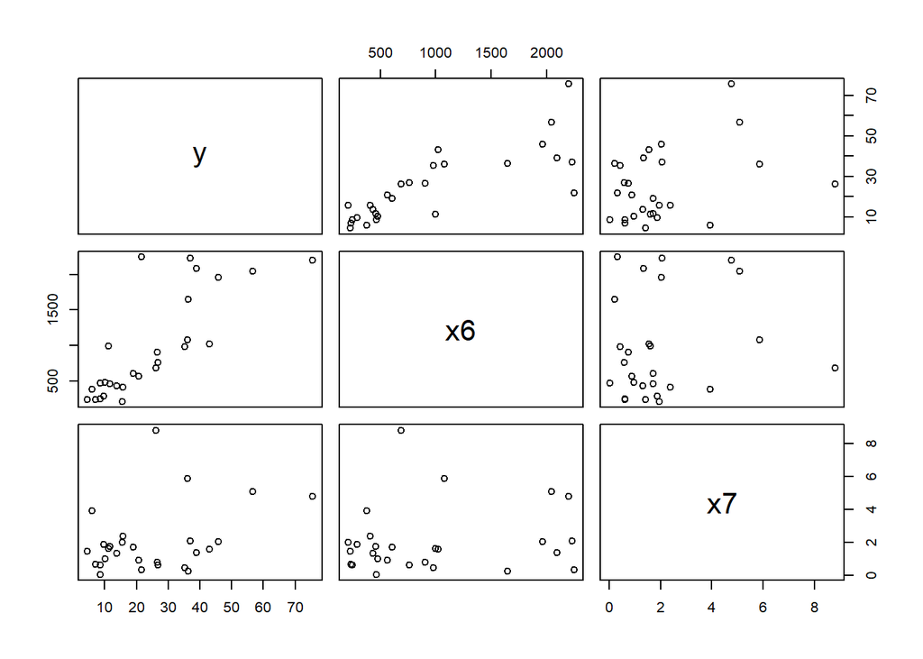

```r
chemical.subset = chemical[c("y", "x6", "x7")]
pairs(chemical.subset)
```

Based on the pairs plot, it seems that there is a strong linear relationship between x6 and y. It’s harder to tell for x7 and y, but it seems like there is a very slight linear relationship between the two.

4. Plot the residual errors against the regressor variables. What assumption of linear model can be checked using this plot? Report your finding.

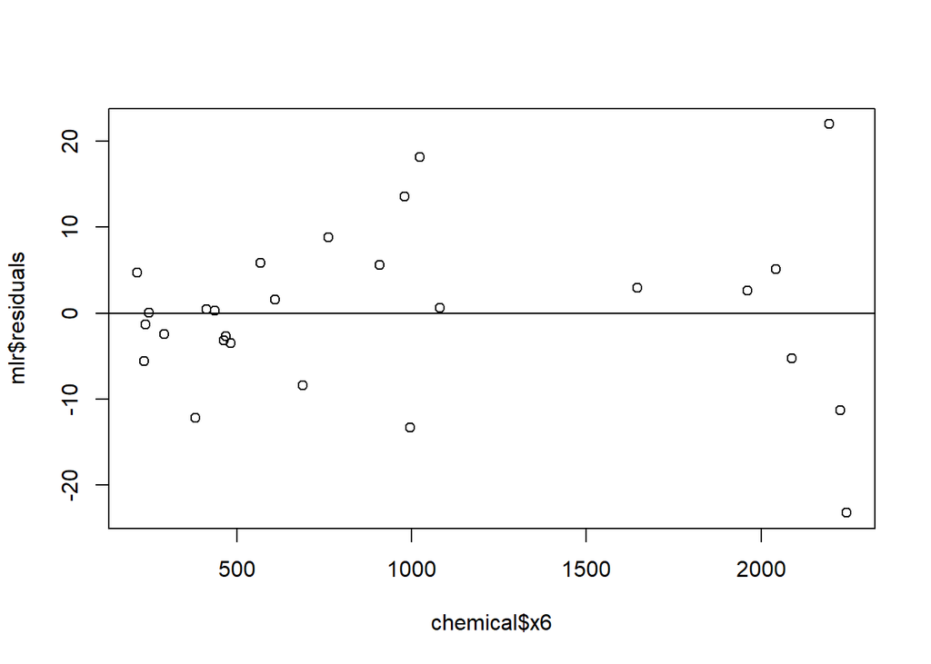

```r
plot(chemical$x6, mlr$residuals)
abline(h=0)
```

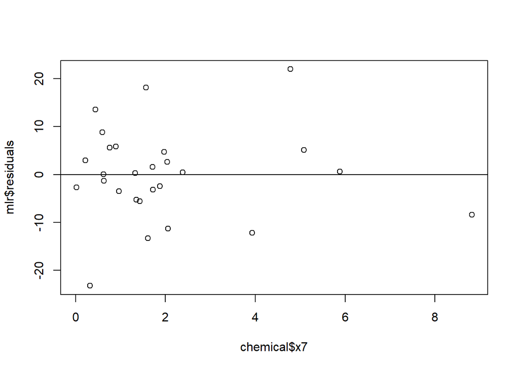

```r
plot(chemical$x7, mlr$residuals)
abline(h=0)
```

5. Plot the residual errors against the fitted values. What assumption of linear model can be checked using this plot? Report your finding.

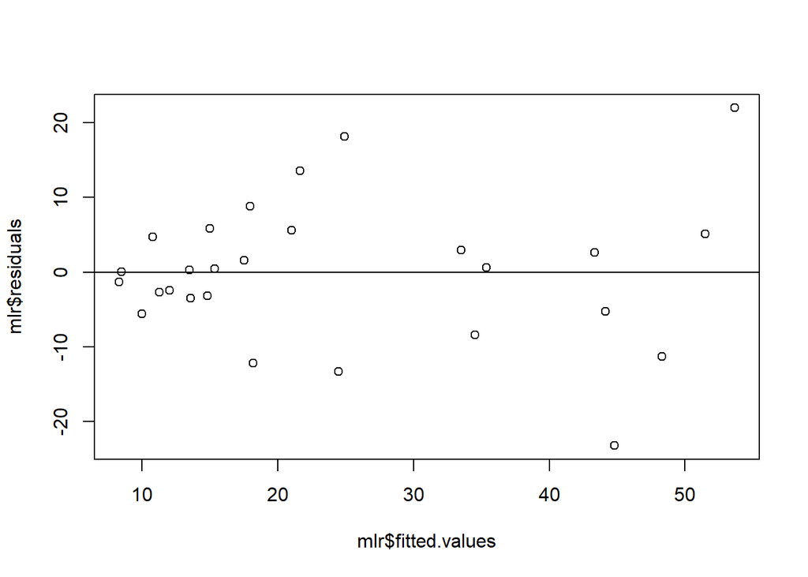

```r
plot(mlr$fitted.values, mlr$residuals)
abline(h=0)
```

Here we are checking for a 0 mean and a constant variance. The mean does seem to be 0, but the variance goes from small to large as we go from left to right on this plot.

6. Plot the residual errors against the row numbers sorted by regressor variables. What assumption of linear model can be checked using this plot? Report your finding.

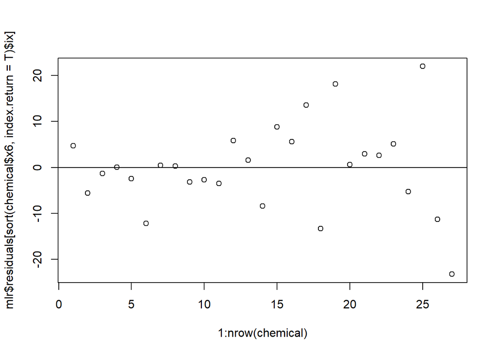

```r
plot(1:nrow(chemical), mlr$residuals[sort(chemical$x6, index.return=T)$ix],)
abline(h=0)
```

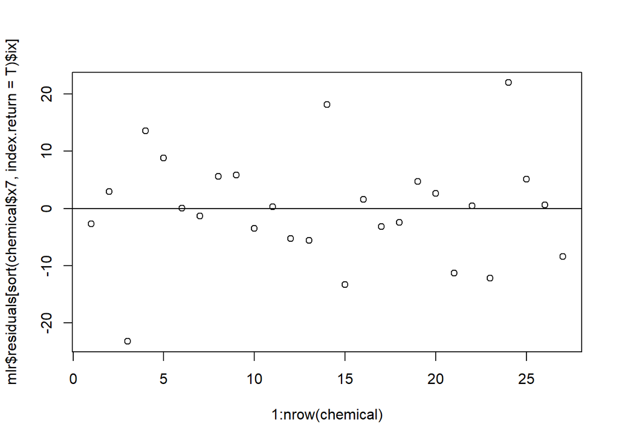

```r
plot(1:nrow(chemical), mlr$residuals[sort(chemical$x7, index.return=T)$ix],)
abline(h=0)
```

Here we are checking on independence. It is hard to say that there is any discernable pattern for x7 or x6. However, it does look like x6 has differing variability amongst the error terms. Other than this, both plots do seem to be centered on a mean of 0.

7. Construct a normal probability plot. What assumption of linear model can be checked using this plot? Report your finding.

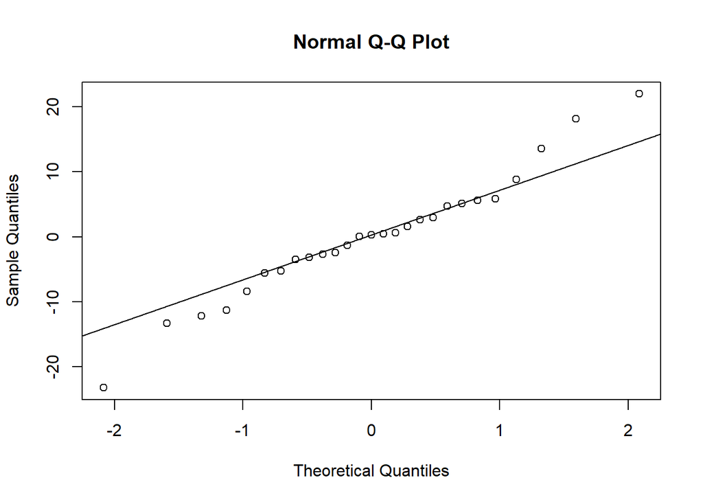

```r
qqnorm(mlr$residuals)
qqline(mlr$residuals)
```

8. Perform Shapiro-Wilk test for normality. Report your finding.

```r
shapiro.test(mlr$residuals)
```

```
##
##  Shapiro-Wilk normality test
##
## data:  mlr$residuals
## W = 0.97358, p-value = 0.6981
```

H0: the errors follow a normal distribution vs. H1: the errors do not follow normal distribution

The shapiro test here gives a p-value of 0.6981. This means that we fail to reject the null, meaning that we have some evidence that the errors do in fact follow the normal distribution.

Q2 ################################################################################

Q2. Consider the following data set from a windmill.

1. Fit a SLR model by regressing y on x. Write the equation of the fitted model.

```r
windmill = read.csv("./windmill.csv")
slr = lm(y ~ x, data=windmill)
summary(slr)
```

```
##
## Call:
## lm(formula = y ~ x, data = windmill)
##
## Residuals:
##      Min       1Q   Median       3Q      Max
## -0.59869 -0.14099  0.06059  0.17262  0.32184
##
## Coefficients:
##             Estimate Std. Error t value Pr(>|t|)
## (Intercept)  0.13088    0.12599   1.039     0.31
## x            0.24115    0.01905  12.659 7.55e-12 ***
## ---
## Signif. codes:  0 '***' 0.001 '**' 0.01 '*' 0.05 '.' 0.1 ' ' 1
##
## Residual standard error: 0.2361 on 23 degrees of freedom
## Multiple R-squared:  0.8745, Adjusted R-squared:  0.869
## F-statistic: 160.3 on 1 and 23 DF,  p-value: 7.546e-12
```

Equation of fitted line: y_hat = 0.13088 + 0.24115(x)

2. State the assumptions about linear regression that you made for fitting the above model.
1. The relationship between y and x is not exactly linear
2. Zero mean and constant variance of error terms is not satisfied
3. Errors are uncorrelated
4. Errors are normally distributed
3. Verify each assumption and report your finding.
1. Check for linearity

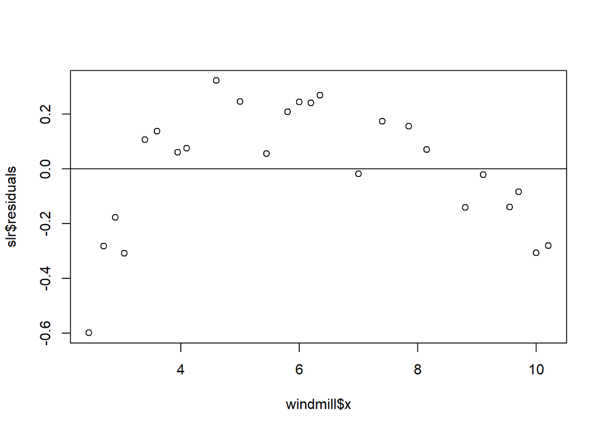

```r
plot(windmill$x, slr$residuals)
abline(h=0)
```

```r
#plot(dat$x, dat$y)
```

Here we are checking for linearity.Base one the scatter plot, we can see that the relationship between x and y is not exactly linear

2. Check for zero mean and constant variance of random error

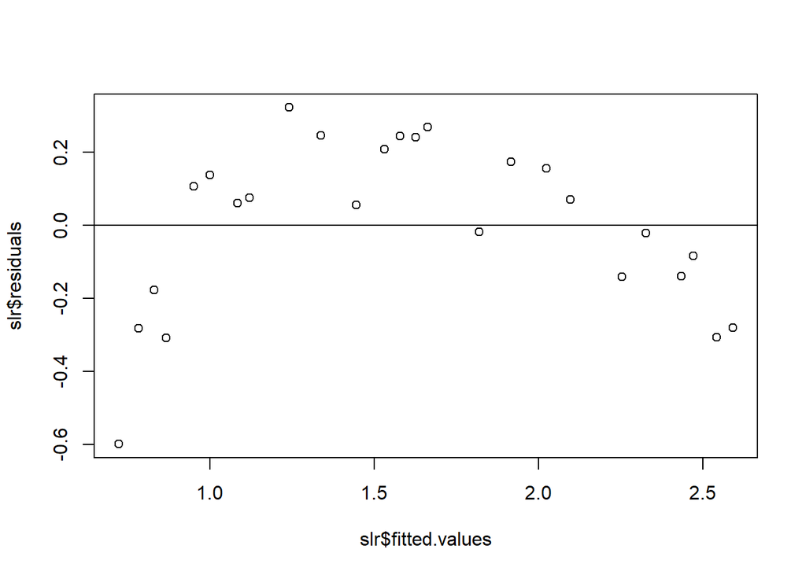

```r
plot(slr$fitted.values, slr$residuals)
abline(h=0)
```

The residual plot for checking zero mean and constant variance of error terms shows non-random pattern. As we scan from left to right the vertical mean changes from negative to positive and then negative within thin vertical strips. This is violating the zero-mean assumption. The spread of the residual across the thin strips are not uniform as well. This suggests non-constant variance for error terms.

3. Check for independence of random error

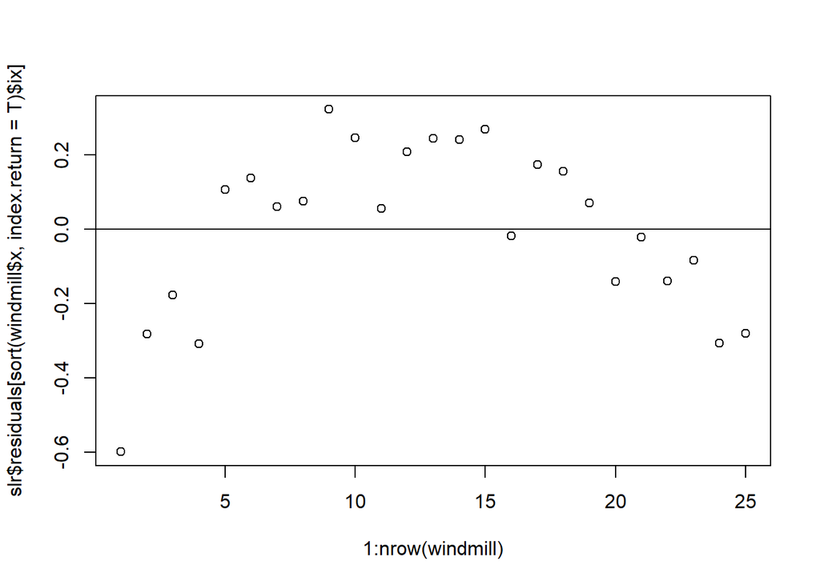

```r
plot(1:nrow(windmill), slr$residuals[sort(windmill$x, index.return=T)$ix],)
abline(h=0)
```

4. Check for normality of random error

[figure not shown]

```r
qqnorm(mlr$residuals)
qqline(mlr$residuals)
```

```r
shapiro.test(mlr$residuals)
```

[output not shown]

H0: the errors follow a normal distribution vs. H1: the errors do not follow normal distribution

4. If some of the model assumptions are violated apply an appropriate transformation and fit the model again.

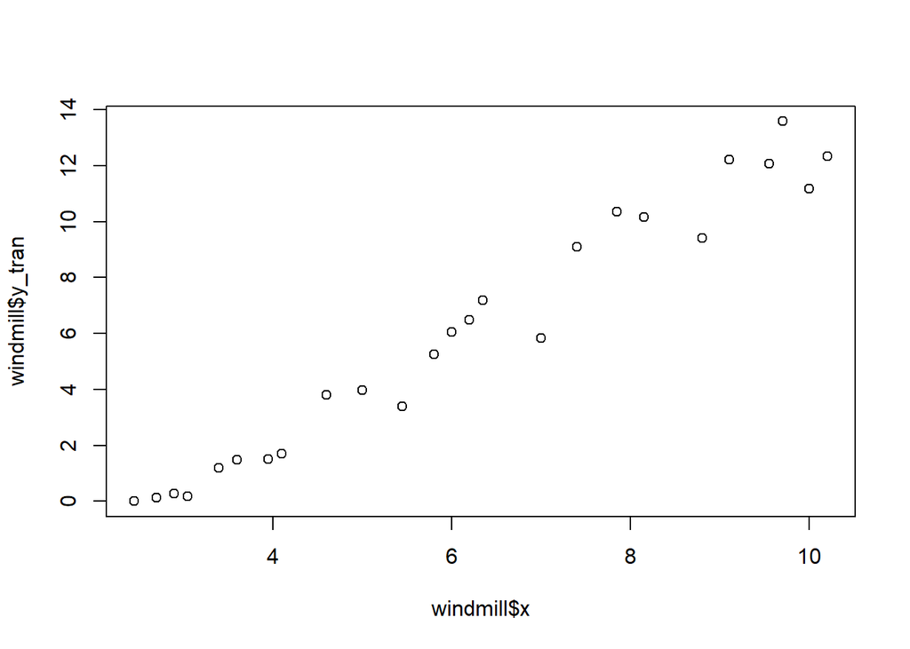

```r
windmill$y_tran <- (windmill$y)^3
plot(windmill$x, windmill$y_tran)
```

```r
slr2 <- lm(y_tran ~ x, data=windmill)
summary(slr2)
```

```
##
## Call:
## lm(formula = y_tran ~ x, data = windmill)
##
## Residuals:
##      Min       1Q   Median       3Q      Max
## -1.64998 -0.60824  0.04504  0.55978  1.36562
##
## Coefficients:
##             Estimate Std. Error t value Pr(>|t|)
## (Intercept) -4.85763    0.47101  -10.31 4.26e-10 ***
## x            1.76280    0.07122   24.75  < 2e-16 ***
## ---
## Signif. codes:  0 '***' 0.001 '**' 0.01 '*' 0.05 '.' 0.1 ' ' 1
##
## Residual standard error: 0.8825 on 23 degrees of freedom
## Multiple R-squared:  0.9638, Adjusted R-squared:  0.9622
## F-statistic: 612.7 on 1 and 23 DF,  p-value: < 2.2e-16
```

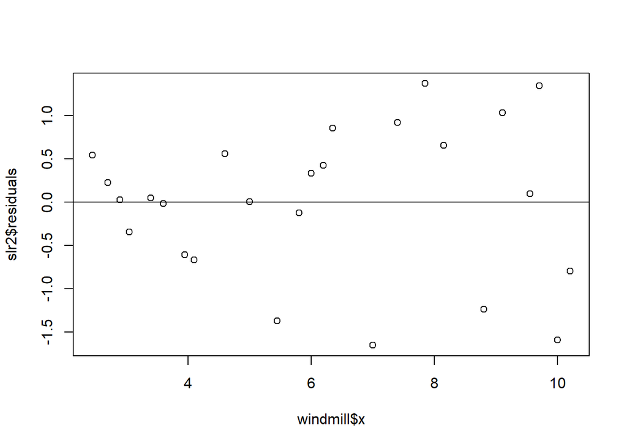

```r
plot(windmill$x, slr2$residuals)
abline(h=0)
```

We notice a significant improvement in the plot. The x vs y indicates an almost linear relationship.

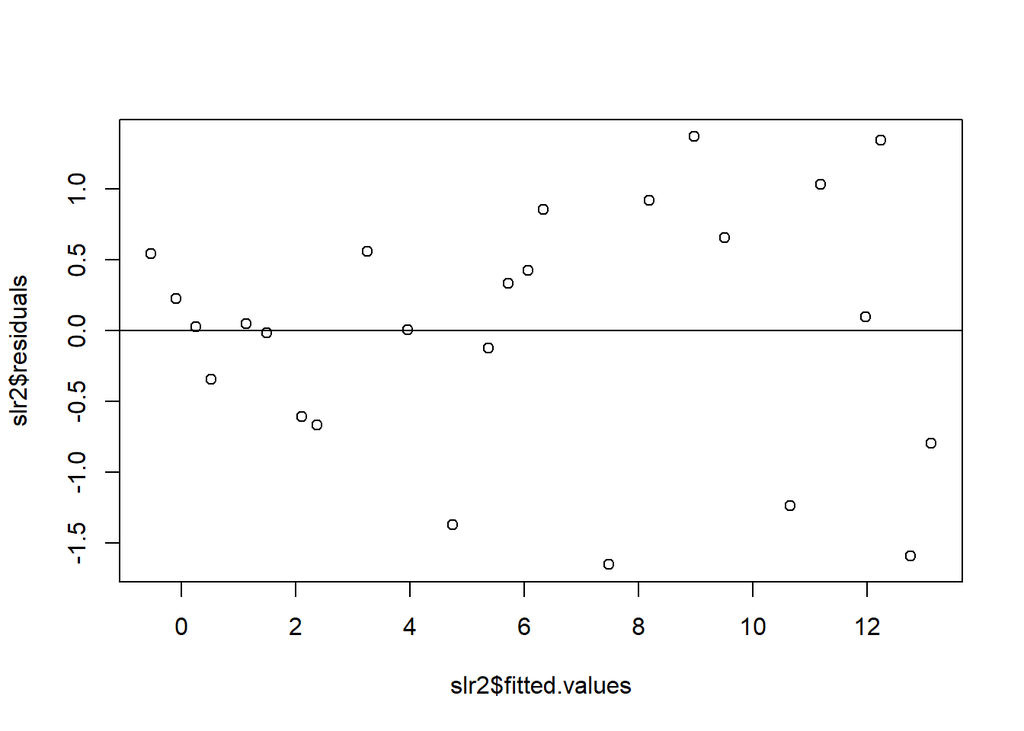

```r
plot(slr2$fitted.values, slr2$residuals)
abline(h=0)
```

3. Errors are uncorrelated

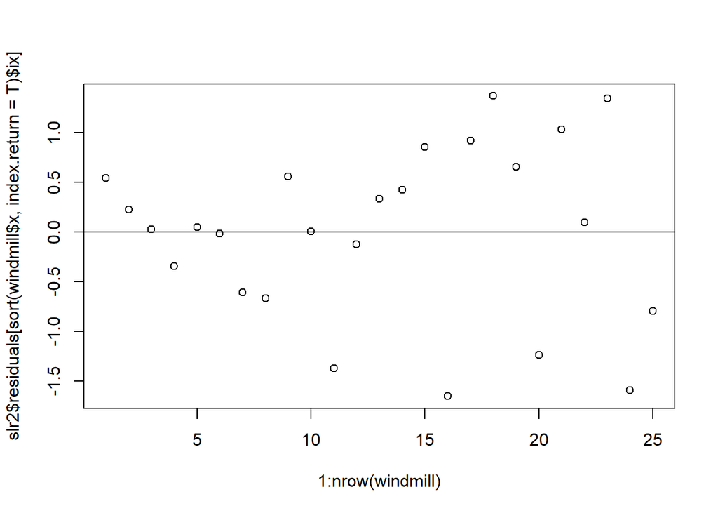

```r
plot(1:nrow(windmill), slr2$residuals[sort(windmill$x, index.return=T)$ix],)
abline(h=0)
```

d) Errors are normally distributed

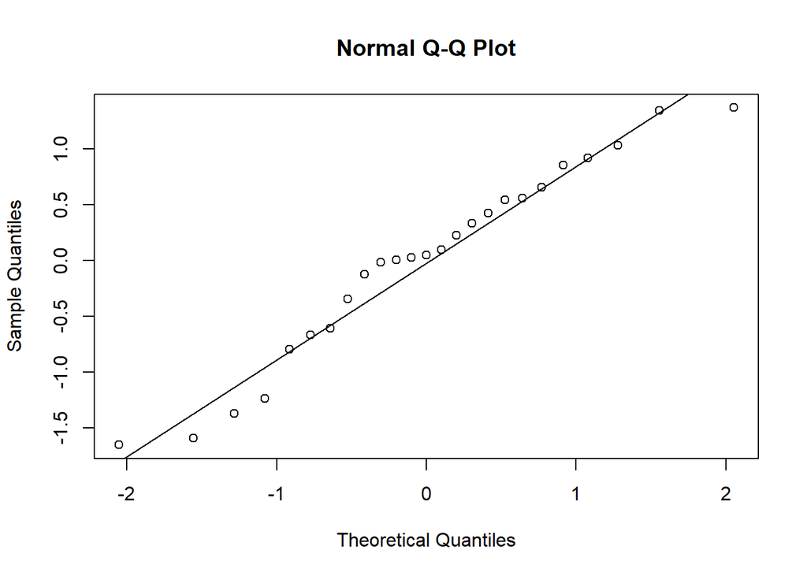

```r
qqnorm(slr2$residuals)
qqline(slr2$residuals)
```

```r
shapiro.test(slr2$residuals)
```

```
##
##  Shapiro-Wilk normality test
##
## data:  slr2$residuals
## W = 0.95764, p-value = 0.3696
```

6. Estimate the mean DC_output for where wind_velocity = 5 mph. Prediction for mean y_tran

```r
newwindmill <- data.frame(x=5)
predict(slr2, newdata = newwindmill, interval = "confidence", level = 0.95)
```

```
##        fit      lwr      upr
## 1 3.956375 3.554983 4.357767
```

Prediction on original scale

```r
(predict(slr2, newdata = newwindmill, interval = "confidence", level = 0.95))^(1/3)
```

```
##        fit      lwr      upr
## 1 1.581609 1.526204 1.633383
```

We got the mean DC_output for where wind_velocity = 5 mph fit lwr upr 1.581609 1.526204 1.633383